# Avaluació de cues amb arribades per lots $G^{[P]}/G/1$

6/3/2021

# Introducció

En aquest petit informe mostrarem els resultats de la implementació d’un programa que ens permeti avaluar la recurrència d’una cua $G^{[P]}/G/1$.

Les distribucions que tenim són les següents:

- Distribucions del temps entre arribades (corresponents a paquets de $p_i$ clients): **Exponencial** amb $E(\tau) = 82 \rightarrow \lambda = \frac{1}{82}$
- Distribucions de temps de servei (corresponent a cada client): **4-Erlang** amb $E(x_i) = 26,1818$

La distribució del número de clients $p_i$ en cada paquet $i$ és:

| j | $Prob(p_i=j)$ |
| --- | --- |
| 1 | 0,125 |
| 2 | 0,275 |
| 3 | 0,350 |
| 4 | 0,250 |

# Aproximació teòrica

Abans de fer la implementació del programa , calculem els valors de $\rho$, $L$, $L_q$, $W$ i $W_q$ (teòrics) mitjançant l’**aproximació d’Allen Cuneen**, que posteriorment, compararem amb els valors simulats.

Si la distribució del temps entre servei dels clients és una 4-Erlang, hem de calcular la distribució de servei dels paquets. S’ha de tenir en compte que els paquets poden ser de 1, 2, 3 o 4 clients amb les probabilitats corresponents a la distribució de $p_i$.

$E(x_i) = \frac{4}{\alpha}= 26.1818 \rightarrow \alpha = 0.1527779$

En el cas de que hi hagi 1 client per paquet, l’esperança del temps de servei del paquet serà de $E(X^{[1]}) = 26.1818$, en cas que hi hagi 2 clients per paquet $E(X^{[2]}) = 2 \cdot \frac{4}{\alpha} = 52.3636$, en cas que hi hagi 3 clients per paquet $E(X^{[3]}) = 2 \cdot \frac{4}{\alpha} = 78.5454$, i en cas que en siguin 4, $E(X^{[4]}) = 2 \cdot \frac{4}{\alpha} = 104.7272$

De tal manera que l’esperança del temps de servei dels paquets serà:

$$E(X) = 0.125\cdot E(X^{[1]}) +
0.275\cdot E(X^{[2]}) + 0.350\cdot E(X^{[3]}) + 0.250\cdot E(X^{[4]}) =
71.3454$$

La variància de la distribució del temps de servei de paquets la podem calcular:

$$V(X) = 0.125\cdot (E(X^{[1]}) -E(X))^2+
0.275\cdot (E(X^{[2]}) -E(X))^2 + 0.350\cdot (E(X^{[3]}) -E(X))^2 +
0.250\cdot (E(X^{[4]}) -E(X))^2 = 650.7839$$

Per veure els càlculs de la distribució del temps de servei de paquets anar a l’*ANNEX 1*.

El coeficient de desviació serà: $C_X = \frac{\sqrt{V(X)}}{E(X)} = 0.3575628$.

Per tant, el model de cues dels paquets serà **$M/ G/ 1$** on $\lambda = \frac{1}{82}$ i $\mu = \frac{1}{71.3454}$.

El factor de càrrega és $\rho = \frac{\lambda}{\mu} = 0.8700659$.

L’aproximació d’**Allen Cuneen** és la següent:

$$L_q \thickapprox Lq_{M/M/1} \cdot
\frac{C_{\tau}^2 + C_X^2 }{2} = \frac{\rho^2}{1-\rho} \cdot
\frac{C_{\tau}^2 + C_X^2 }{2} = 3.285512$$

A partir de les fòrmules de Little podem calcular la resta de magnituds fonamentals:

- Ocupacio mitjana al S.E.: $L = Lq + \rho = 4.155578$
- Temps mig de permenència al S.E.: $W = \frac{L}{\lambda } = 340.7574$
- Temps mig de permenència en cua: $Wq = \frac{Lq}{\lambda } = 269.412$

Per veure els càlculs d’aquestes magnituds anar a l’*ANNEX 2*.

# Generador de variables aleatòries

Generació **$p_i$** (número de clients per paquet):

```r
generacio_p <- function (u){
  if (u <= 0.125){return(1)}else if (u>0.125 && u<=0.4){return(2)}
  else if(u>0.4 && u<=0.75) {return(3)}else  {return(4)}
}
```

Generació del **temps entre arribades** per a paquets de mida $p_i$ clients:

```r
arribades <- function(u){
return(-log(runif(u))/lambda)
  }
```

Generació del **temps de servei** per a clients:

```r
servei <- function(u){
return(-log(prod(runif(u)))/alpha)
}
```

# Implementació del programa

Per tal de dur a terme el bucle que ens calcula tota la simulació del model de cues, s’ha realitzat mitjançant codi R. Per veure el codi, anar al document *Informe.Rmd* o a l’*ANNEX 3*. Els resultats de la simulació que es mostren a la pràctica, corresponen a una simulació d’un total de n = 10.000 paquets.

# Presentació de resultats de la simulació

## El factor de càrrega $\rho$

```r
mean(X)/mean(tau)
```

```
## [1] 0.8639986
```

## La ocupació mitjana del S.E. $\mathcal{L}$ i de la cua $\mathcal{L}_q$ en número de paquets.

L paquets:

```r
Lresultat = Ltotal/t[n];  Lresultat
```

```
## [1] 4.223545
```

Lq paquets:

```r
Lqresultat = Ltotalq/t[n];  Lqresultat
```

```
## [1] 3.35946
```

### Evolució de $\mathcal{L}$ i $\mathcal{L}_q$ paquets

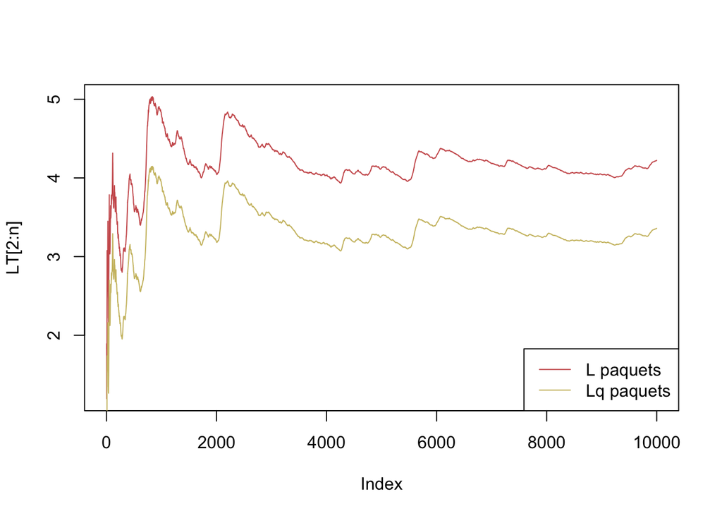

## La ocupació mitjana del S.E. $L$ i de la cua $L_q$ en número de clients.

L clients:

```r
Lresultatc = Ltotalc/t[n];  Lresultatc
```

```
## [1] 10.92432
```

Lq clients:

```r
Ltotalqc/t[n]
```

```
## [1] 10.06023
```

### Evolució de $\mathcal{L}$ i $\mathcal{L}_q$ clients:

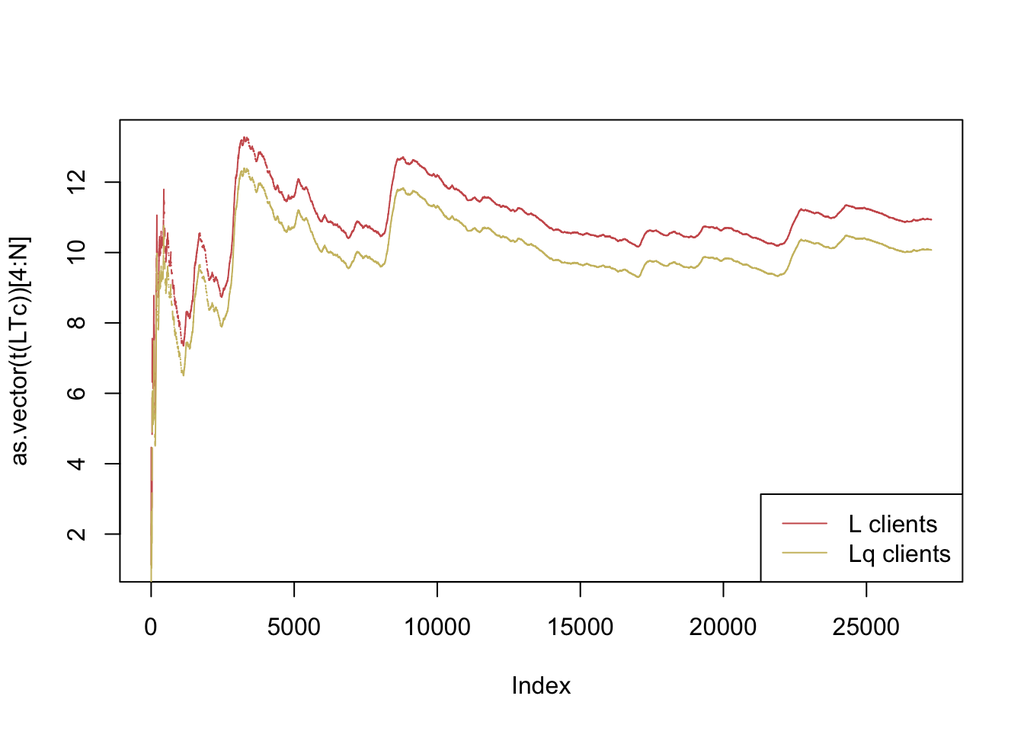

## El temps mig per client de permanència en el S.E $\mathcal{W}$ i en la cua $\mathcal{W_q}$ dels paquets.

W de paquets:

```r
W/n
```

```
## [1] 349.0824
```

Wq de paquets:

```r
Wq/n
```

```
## [1] 277.6645
```

## El temps mig per client de permanència en el S.E $W$ i en la cua $W_q$ dels clients.

W de clients:

```r
Wc/N
```

```
## [1] 331.1007
```

Wq de clients:

```r
Wqc/N
```

```
## [1] 304.9115
```

## Histogrames

**Gràfic temps d’arribada de paquets**

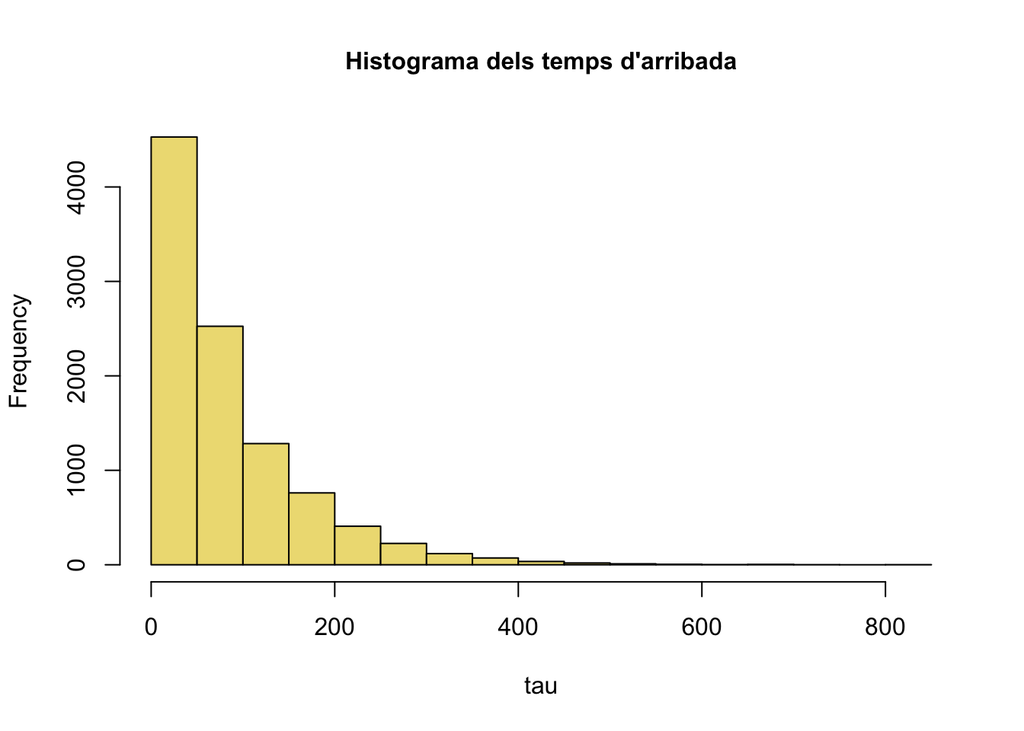

**Gràfic temps de servei de paquets i clients**

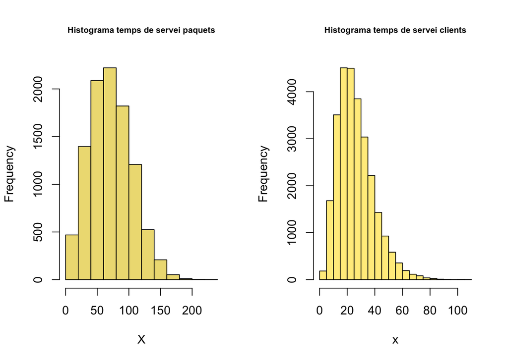

Per veure el codi de la realització dels gràfics anar a l’*ANNEX 4*.

# Comparació resultats de l’aproximació amb la simulació

|  | Simulació Clients | Simulació Paquets | Aproximació (teòrica) paquets |
| --- | --- | --- | --- |
| Wq | 304.91150 | 277.664495 | 269.411963 |
| W | 331.10070 | 349.082430 | 340.757368 |
| Lq | 10.06023 | 3.359460 | 3.285512 |
| L | 10.92432 | 4.223545 | 4.155578 |

Compararem els resultats que hem obtingut de les magnituds corresponents als paquets, tant les magnituds teòriques com les simulades mitjançant el codi implementat. El número de paquets en cua i el número de paquets en el sistema d’espera és molt semblant entre el càlcul teòric i el simulat, per tant, això és bon indicador.